# CPS85 Lab

Ali Doswell, Rob Thoma, Chris, Mike Stiglia, Connor Gunn

February 3, 2015

## Box Plot of Education vs. Wage

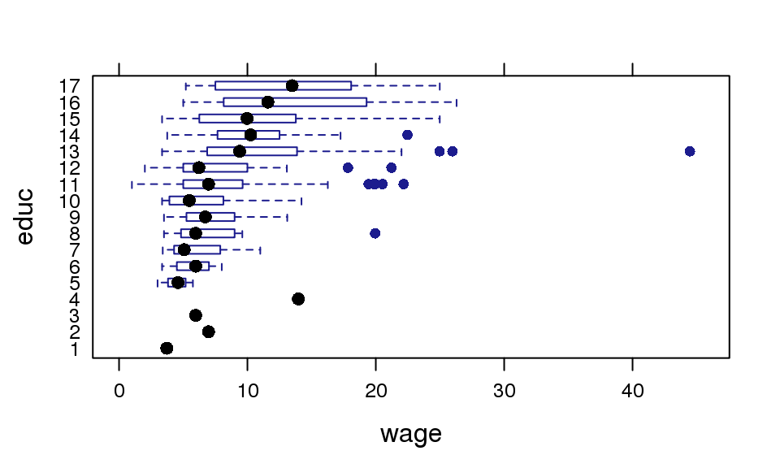

```r
bwplot(educ ~ wage, data=CPS85)
```

This boxplot shows that as the number of years of education increases then the median of the wage increases as well. Up to twelve years of education, those in the data set experienced a similar earnings potential. However, for every year after the twelfth year of education,earnings potential seems to increase at a greater rate.

## Histogram of Age

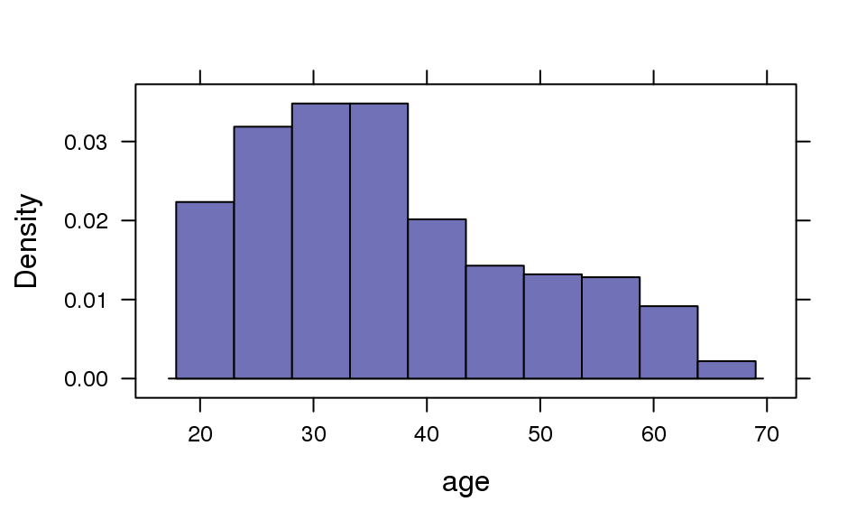

```r
histogram(~age, data=CPS85)
```

This histogram shows that the median age is around the low 30’s. This is a unimodal, right-skewed histogram. The ages range between 20 and 70.

## Scatter Plot of Wage vs. Age

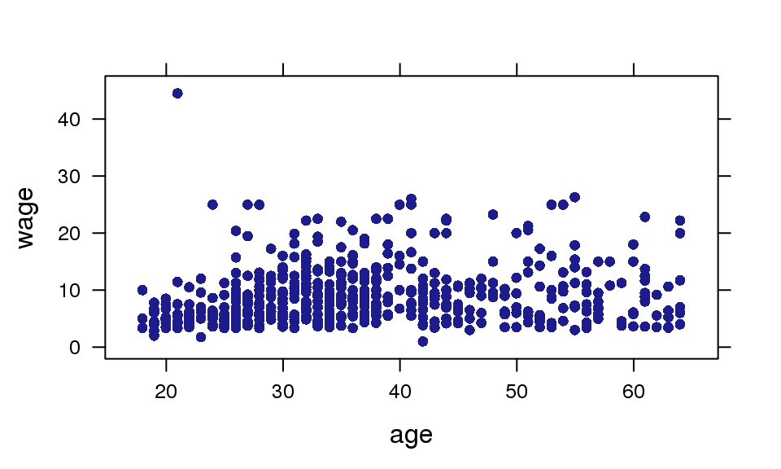

```r
xyplot(wage~age, data=CPS85)
```

This xy plot shows us that there was a higher concentration of people that were surveyed in the age group below forty than above. The data becomes more scattered ther higher we go into the age range, as there are less data points. This could be a result of retirement, as the older age group is likely to have less people availbable to survey due to this phenomenon. Further, the age group between 30 and 40 years old seems to have a higher average wage than those in the 20 to 30 year range.